# 13 Prepare : Cameras, Lights

## Objectives

- We will cover cameras and lights in ThreeJS
- Look at shadows, fog and skybox

## Camera

There are two main types of cameras used in computer graphics. Prespective and orthographic. The following content has examples from [threejsfundamentals.org](https://threejsfundamentals.org/threejs/lessons/threejs-cameras.html)

Here is a great video on [ThreeJS cameras in games](https://www.youtube.com/watch?v=FwcXultcBl4)

### PerspectiveCamera

A perspective camera gives a 3d view where objects in the distance appear smaller than things up close. In order to view objects closer and further, this camera uses a frustum.

> In 3D computer graphics, the view frustum (also called viewing frustum) is the region of space in the modeled world that may appear on the screen; it is the field of view of a perspective virtual camera system.

> The view frustum is typically obtained by taking a frustum—that is a truncation with parallel planes—of the pyramid of vision, which is the adaptation of (idealized) cone of vision that a camera or eye would have to the rectangular viewports typically used in computer graphics. Some authors use pyramid of vision as a synonym for view frustum itself, i.e. consider it truncated.

> The exact shape of this region varies depending on what kind of camera lens is being simulated, but typically it is a frustum of a rectangular pyramid (hence the name). The planes that cut the frustum perpendicular to the viewing direction are called the near plane and the far plane. Objects closer to the camera than the near plane or beyond the far plane are not drawn. Sometimes, the far plane is placed infinitely far away from the camera so all objects within the frustum are drawn regardless of their distance from the camera.

-- [Viewing frustum](https://en.wikipedia.org/wiki/Viewing_frustum)

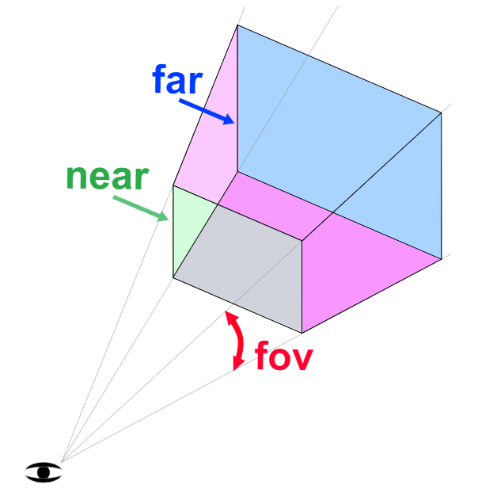

#### ThreeJS Examples

```
const camera = new THREE.PerspectiveCamera( 45, width / height, 1, 1000 );
scene.add( camera );
```

Constructor of the PerspectiveCamera

```
PerspectiveCamera( fov : Number, aspect : Number, near : Number, far : Number )

fov — Camera frustum vertical field of view.
aspect — Camera frustum aspect ratio.
near — Camera frustum near plane.
far — Camera frustum far plane.
```

#### Videos

- https://www.youtube.com/watch?v=KyTaxN2XUyQ

#### Examples

- https://threejsfundamentals.org/threejs/threejs-cameras-perspective.html
- https://threejsfundamentals.org/threejs/threejs-cameras-perspective-2-scenes.html
- https://threejsfundamentals.org/threejs/threejs-cameras-logarithmic-depth-buffer.html

### OrthographicCamera

In this projection mode, an object's size in the rendered image stays constant regardless of its distance from the camera. This can be useful for rendering 2D scenes and UI elements, amongst other things.

> Orthographic projection (sometimes referred to as orthogonal projection, used to be called analemma) is a means of representing three-dimensional objects in two dimensions. It is a form of parallel projection, in which all the projection lines are orthogonal to the projection plane, resulting in every plane of the scene appearing in affine transformation on the viewing surface. The obverse of an orthographic projection is an oblique projection, which is a parallel projection in which the projection lines are not orthogonal to the projection plane.

> The term orthographic is sometimes reserved specifically for depictions of objects where the principal axes or planes of the object are also parallel with the projection plane, but these are better known as multiview projections. Furthermore, when the principal planes or axes of an object in an orthographic projection are not parallel with the projection plane, but are rather tilted to reveal multiple sides of the object, the projection is called an axonometric projection. Sub-types of multiview projection include plans, elevations and sections. Sub-types of axonometric projection include isometric, dimetric and trimetric projections.

-- [Orthographic projection](https://en.wikipedia.org/wiki/Orthographic_projection)

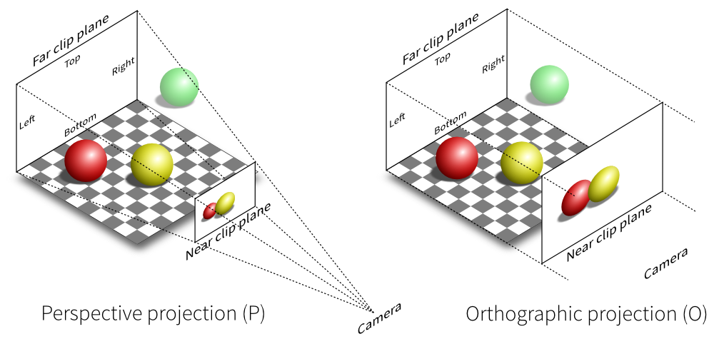

#### ThreeJS Examples

```
const camera = new THREE.OrthographicCamera( width / - 2, width / 2, height / 2, height / - 2, 1, 1000 );
scene.add( camera );
```

Constructor of the OrthographicCamera

```
OrthographicCamera( left : Number, right : Number, top : Number, bottom : Number, near : Number, far : Number )

left — Camera frustum left plane.
right — Camera frustum right plane.
top — Camera frustum top plane.
bottom — Camera frustum bottom plane.
near — Camera frustum near plane.
far — Camera frustum far plane.
```

#### Videos

- https://www.youtube.com/watch?v=X_n7Adjoiwk
- https://www.youtube.com/watch?v=k3adBAnDpos&list=RDCMUCBVCi5JbYmfG3q5MEuoWdOw&start_radio=1&t=116

#### Examples

- https://threejs.org/examples/#webgl_camera
- https://codepen.io/Jobarbo/pen/zZMwVm
- https://threejsfundamentals.org/threejs/threejs-cameras-orthographic-2-scenes.html

## Lights

In this section, we will be looking at the different types of lights in ThreeJS with examples.

### AmbientLight

This light globally illuminates all objects in the scene equally.This light cannot be used to cast shadows as it does not have a direction.

```
const color = 0xFFFFFF;
const intensity = 1;
const light = new THREE.AmbientLight(color, intensity);
scene.add(light);
```

- https://threejsfundamentals.org/threejs/threejs-lights-ambient.html

### HemisphereLight

A light source positioned directly above the scene, with color fading from the sky color to the ground color. This light cannot be used to cast shadows.

```
const skyColor = 0xB1E1FF;  // light blue
const groundColor = 0xB97A20;  // brownish orange
const intensity = 1;
const light = new THREE.HemisphereLight(skyColor, groundColor, intensity);
scene.add(light);
```

- https://threejs.org/examples/#webgl_lights_hemisphere

### DirectionalLight

A light that gets emitted in a specific direction. This light will behave as though it is infinitely far away and the rays produced from it are all parallel. The common use case for this is to simulate daylight; the sun is far enough away that its position can be considered to be infinite, and all light rays coming from it are parallel.

```
const color = 0xFFFFFF;
const intensity = 1;
const light = new THREE.DirectionalLight(color, intensity);
light.position.set(0, 10, 0);
light.target.position.set(-5, 0, 0);
scene.add(light);
scene.add(light.target);
```

- https://threejsfundamentals.org/threejs/threejs-lights-directional.html

### PointLight

A light that gets emitted from a single point in all directions. A common use case for this is to replicate the light emitted from a bare lightbulb.

```
const color = 0xFFFFFF;
const intensity = 1;
const light = new THREE.PointLight(color, intensity);
light.position.set(0, 10, 0);
scene.add(light);
```

- https://threejsfundamentals.org/threejs/threejs-lights-point.html
- https://threejs.org/examples/#webgl_lights_pointlights

### SpotLight

This light gets emitted from a single point in one direction, along a cone that increases in size the further from the light it gets.

```
const color = 0xFFFFFF;
const intensity = 1;
const light = new THREE.SpotLight(color, intensity);
scene.add(light);
scene.add(light.target);

const helper = new THREE.SpotLightHelper(light);
scene.add(helper);
```

- https://threejsfundamentals.org/threejs/threejs-lights-spot-w-helper.html

### RectAreaLight

RectAreaLight emits light uniformly across the face a rectangular plane. This light type can be used to simulate light sources such as bright windows or strip lighting.

```
const color = 0xFFFFFF;
const intensity = 5;
const width = 12;
const height = 4;
const light = new THREE.RectAreaLight(color, intensity, width, height);
light.position.set(0, 10, 0);
light.rotation.x = THREE.MathUtils.degToRad(-90);
scene.add(light);

const helper = new RectAreaLightHelper(light);
light.add(helper);
```

- https://threejsfundamentals.org/threejs/threejs-lights-rectarea.html
- https://threejs.org/examples/#webgl_lights_rectarealight

## Fog

Here is a link to [Three.js Fog](https://threejsfundamentals.org/threejs/lessons/threejs-fog.html) at threejsfundamentals.org.

> Fog in a 3D engine is generally a way of fading to a specific color based on the distance from the camera. In three.js you add fog by creating Fog or FogExp2 object and setting it on the scene's fog property.

> Fog lets you choose near and far settings which are distances from the camera. Anything closer than near is unaffected by fog. Anything further than far is completely the fog color. Parts between near and far fade from their material color to the fog color.

> There's also FogExp2 which grows exponentially with distance from the camera.

### ThreeJS Example

```
const scene = new THREE.Scene();
{
  const color = 0xFFFFFF;  // white
  const near = 10;
  const far = 100;
  scene.fog = new THREE.Fog(color, near, far);
}
```

- https://threejsfundamentals.org/threejs/threejs-fog.html

## Shadows

Please read the [threejsfundamentals.org article on shadows](https://threejsfundamentals.org/threejs/lessons/threejs-shadows.html).

### Videos

- https://www.youtube.com/watch?v=AUF15I3sy6s

### ThreeJS Examples

- https://threejsfundamentals.org/threejs/threejs-shadows-fake.html
- https://threejsfundamentals.org/threejs/threejs-shadows-point-light.html

## BackGrounds and Skybox

Please refer to [threejsfundamentals.org](https://threejsfundamentals.org/threejs/lessons/threejs-backgrounds.html)

### Backgrounds

You can add a background to ThreeJS through HTML. Adding a CSS style:

```
html, body {
  height: 100%;
  margin: 0;
}
#c {
  width: 100%;
  height: 100%;
  display: block;
  background: url(https://threejsfundamentals.org/threejs/resources/images/daikanyama.jpg) no-repeat center center ;
  background-size: cover;
}
```

And in the HTML, you use:

```
function main() {
  const canvas = document.querySelector('#c');
  const renderer = new THREE.WebGLRenderer({
    canvas,
    alpha: true,
  });
```

#### ThreeJS Example

- https://threejsfundamentals.org/threejs/threejs-background-scene-background-fixed-aspect.html

### Skybox

A skybox is a box with the sky draw on it. We put the camera inside the box and it looks like there is a sky in the background.

Here is an example of using 6 images for each side of the cube.

```
{
  const loader = new THREE.CubeTextureLoader();
  const texture = loader.load([
    'resources/images/cubemaps/computer-history-museum/pos-x.jpg',
    'resources/images/cubemaps/computer-history-museum/neg-x.jpg',
    'resources/images/cubemaps/computer-history-museum/pos-y.jpg',
    'resources/images/cubemaps/computer-history-museum/neg-y.jpg',
    'resources/images/cubemaps/computer-history-museum/pos-z.jpg',
    'resources/images/cubemaps/computer-history-museum/neg-z.jpg',
  ]);
  scene.background = texture;
}
```

#### ThreeJS example

- https://threejsfundamentals.org/threejs/threejs-background-cubemap.html